# Proyecto Final de Análisis de Datos con Lenguaje R

Simón Jalil

2025-05-06

Este proyecto consiste en un análisis exploratorio y visual del catálogo de títulos de Netflix utilizando el lenguaje R. Se examinan aspectos como la distribución entre películas y series, la evolución temporal de las incorporaciones, las clasificaciones, la procedencia geográfica del contenido, los géneros más frecuentes y los directores y actores con mayor presencia. Los resultados se presentan mediante tablas y gráficos con el objetivo de identificar patrones y tendencias relevantes.

```r
# --- Cargar el dataset ---
netflix <- read.csv("netflix_titles.csv", stringsAsFactors = FALSE)
```

## 1. Análisis Exploratorio

A continuación se realiza un análisis general del contenido disponible en Netflix, observando la distribución entre películas y series, la evolución temporal de los títulos agregados, y las clasificaciones más frecuentes según su rating.

```r
# 1.1 Cantidad de Películas vs Series (tabla)
tibble_1_1 <- netflix %>%
  count(type)
tibble_1_1
```

```
##      type    n
## 1   Movie 6131
## 2 TV Show 2676
```

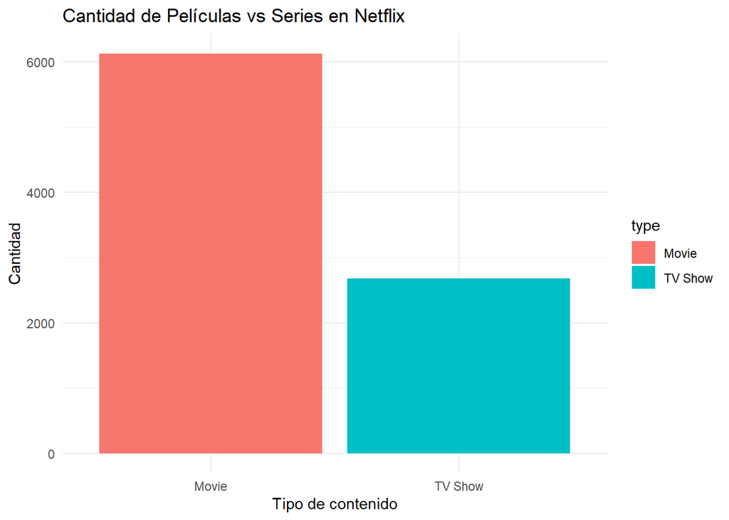

```r
# 1.1 Gráfico
tibble_1_1 %>%
  ggplot(aes(x = type, y = n, fill = type)) +
  geom_col() +
  labs(title = "Cantidad de Películas vs Series en Netflix",
       x = "Tipo de contenido", y = "Cantidad") +
  theme_minimal()
```

```r
# 1.2 Evolución de títulos por año (tabla)
tibble_1_2 <- netflix %>%
  mutate(date_added = mdy(date_added),
         year_added = year(date_added)) %>%
  count(year_added, type) %>%
  filter(!is.na(year_added))
tibble_1_2
```

```
##    year_added    type    n
## 1        2008   Movie    1
## 2        2008 TV Show    1
## 3        2009   Movie    2
## 4        2010   Movie    1
## 5        2011   Movie   13
## 6        2012   Movie    3
## 7        2013   Movie    6
## 8        2013 TV Show    5
## 9        2014   Movie   19
## 10       2014 TV Show    5
## 11       2015   Movie   56
## 12       2015 TV Show   26
## 13       2016   Movie  253
## 14       2016 TV Show  176
## 15       2017   Movie  839
## 16       2017 TV Show  349
## 17       2018   Movie 1237
## 18       2018 TV Show  412
## 19       2019   Movie 1424
## 20       2019 TV Show  592
## 21       2020   Movie 1284
## 22       2020 TV Show  595
## 23       2021   Movie  993
## 24       2021 TV Show  505
```

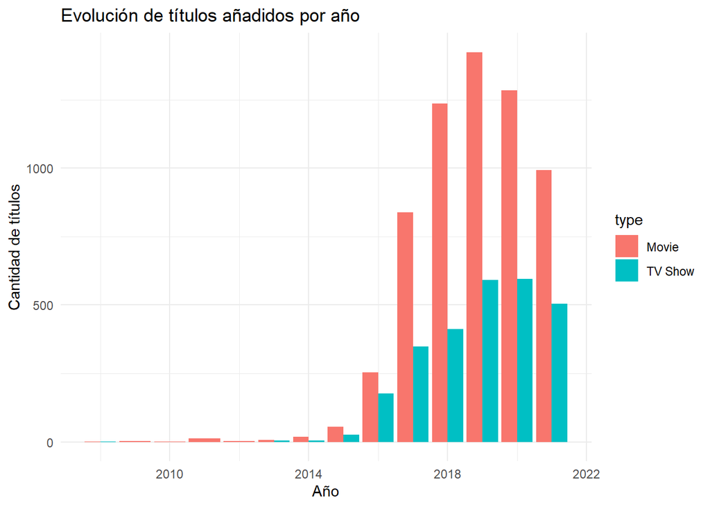

```r
# 1.2 Gráfico
tibble_1_2 %>%
  ggplot(aes(x = year_added, y = n, fill = type)) +
  geom_col(position = "dodge") +
  labs(title = "Evolución de títulos añadidos por año",
       x = "Año", y = "Cantidad de títulos") +
  theme_minimal()
```

```r
# 1.3 Clasificaciones más comunes (tabla)
tibble_1_3 <- netflix %>%
  count(rating, sort = TRUE) %>%
  slice_max(n, n = 10)
tibble_1_3
```

```
##    rating    n
## 1   TV-MA 3207
## 2   TV-14 2160
## 3   TV-PG  863
## 4       R  799
## 5   PG-13  490
## 6   TV-Y7  334
## 7    TV-Y  307
## 8      PG  287
## 9    TV-G  220
## 10     NR   80
```

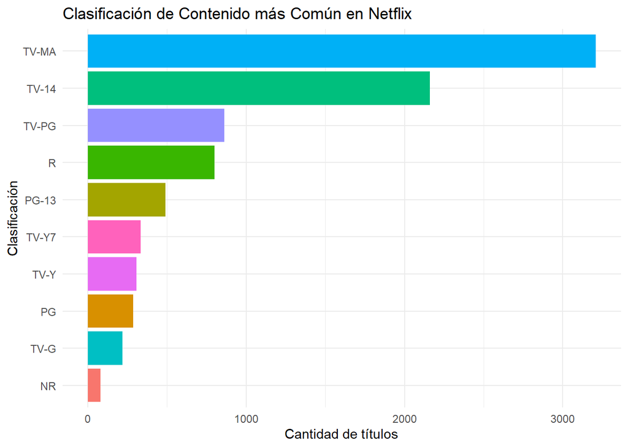

```r
# 1.3 Gráfico
tibble_1_3 %>%
  ggplot(aes(x = reorder(rating, n), y = n, fill = rating)) +
  geom_col(show.legend = FALSE) +
  coord_flip() +
  labs(title = "Clasificación de Contenido más Común en Netflix",
       x = "Clasificación", y = "Cantidad de títulos") +
  theme_minimal()
```

## 2. Análisis Geográfico

Este apartado explora la procedencia geográfica de los títulos. Se destacan los países con mayor cantidad de producciones y se presenta una visualización global de su distribución.

```r
# 2.1 Top países (tabla)
tibble_2_1 <- netflix %>%
  filter(!is.na(country)) %>%
  separate_rows(country, sep = ", ") %>%
  filter(country != "") %>%
  count(country, sort = TRUE) %>%
  slice_max(n, n = 10)
tibble_2_1
```

```
## # A tibble: 10 × 2
##    country            n
##    <chr>          <int>
##  1 United States   3689
##  2 India           1046
##  3 United Kingdom   804
##  4 Canada           445
##  5 France           393
##  6 Japan            318
##  7 Spain            232
##  8 South Korea      231
##  9 Germany          226
## 10 Mexico           169
```

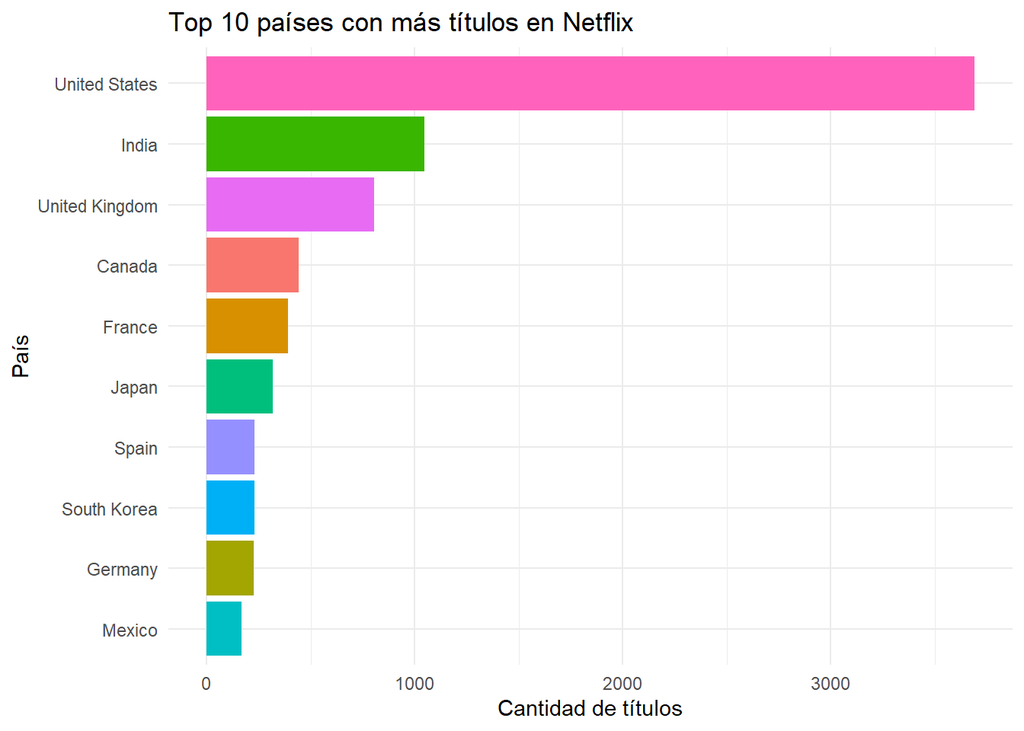

```r
# 2.1 Gráfico
tibble_2_1 %>%
  ggplot(aes(x = reorder(country, n), y = n, fill = country)) +
  geom_col(show.legend = FALSE) +
  coord_flip() +
  labs(title = "Top 10 países con más títulos en Netflix",
       x = "País", y = "Cantidad de títulos") +
  theme_minimal()
```

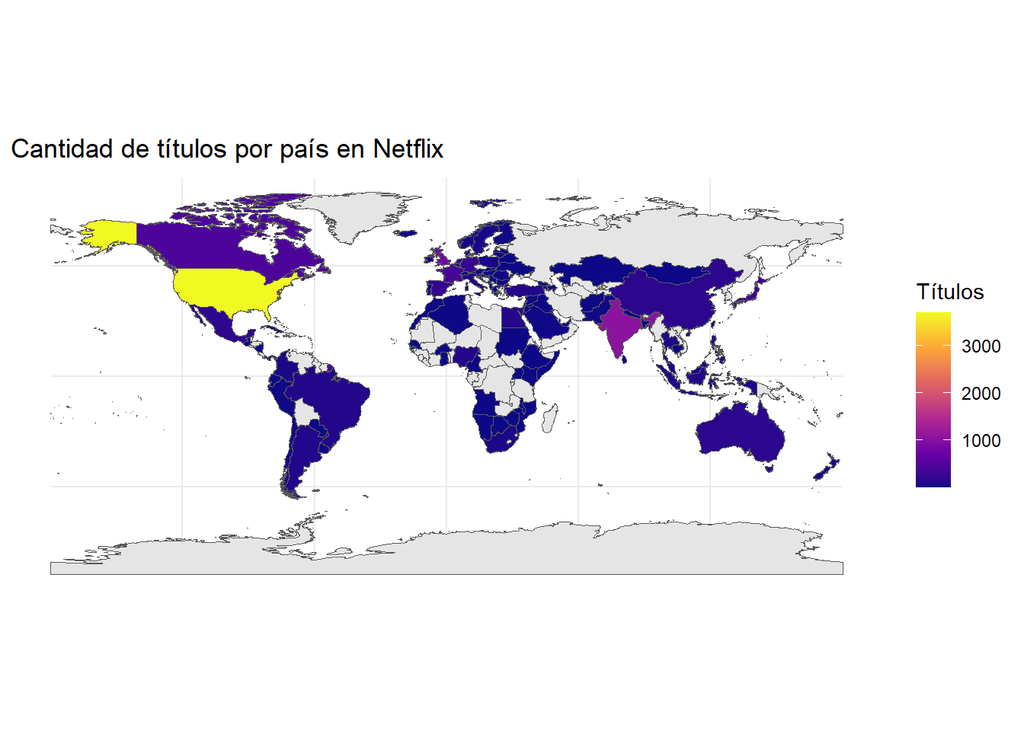

```r
# 2.2 Mapa mundial

# Crear tabla base de países con recuento de títulos
netflix_countries <- netflix %>%
  filter(!is.na(country)) %>%
  separate_rows(country, sep = ", ") %>%
  filter(country != "") %>%
  count(country) %>%
  rename(name = country)

# Corregir nombres de países para que coincidan con el shapefile
netflix_countries <- netflix_countries %>%
  mutate(name = case_when(
    name == "United States" ~ "United States of America",
    name == "Russia" ~ "Russian Federation",
    name == "South Korea" ~ "Republic of Korea",
    name == "North Korea" ~ "Democratic People's Republic of Korea",
    name == "Iran" ~ "Iran (Islamic Republic of)",
    name == "Vietnam" ~ "Viet Nam",
    name == "Bolivia" ~ "Bolivia (Plurinational State of)",
    name == "Venezuela" ~ "Venezuela (Bolivarian Republic of)",
    name == "Tanzania" ~ "United Republic of Tanzania",
    TRUE ~ name
  ))

world <- ne_countries(scale = "medium", returnclass = "sf")
world_netflix <- left_join(world, netflix_countries, by = "name")

ggplot(world_netflix) +
  geom_sf(aes(fill = n)) +
  scale_fill_viridis_c(option = "plasma", na.value = "grey90") +
  labs(title = "Cantidad de títulos por país en Netflix",
       fill = "Títulos") +
  theme_minimal()
```

## 3. Géneros y Duración

Aquí se identifican los géneros más frecuentes entre los títulos de Netflix. Además, se analiza la duración promedio de películas y el promedio de temporadas en las series.

```r
# 3.1 Géneros más frecuentes (tabla)
tibble_3_1 <- netflix %>%
  filter(!is.na(listed_in)) %>%
  separate_rows(listed_in, sep = ", ") %>%
  count(listed_in, sort = TRUE) %>%
  slice_max(n, n = 10)
tibble_3_1
```

```
## # A tibble: 10 × 2
##    listed_in                    n
##    <chr>                    <int>
##  1 International Movies      2752
##  2 Dramas                    2427
##  3 Comedies                  1674
##  4 International TV Shows    1351
##  5 Documentaries              869
##  6 Action & Adventure         859
##  7 TV Dramas                  763
##  8 Independent Movies         756
##  9 Children & Family Movies   641
## 10 Romantic Movies            616
```

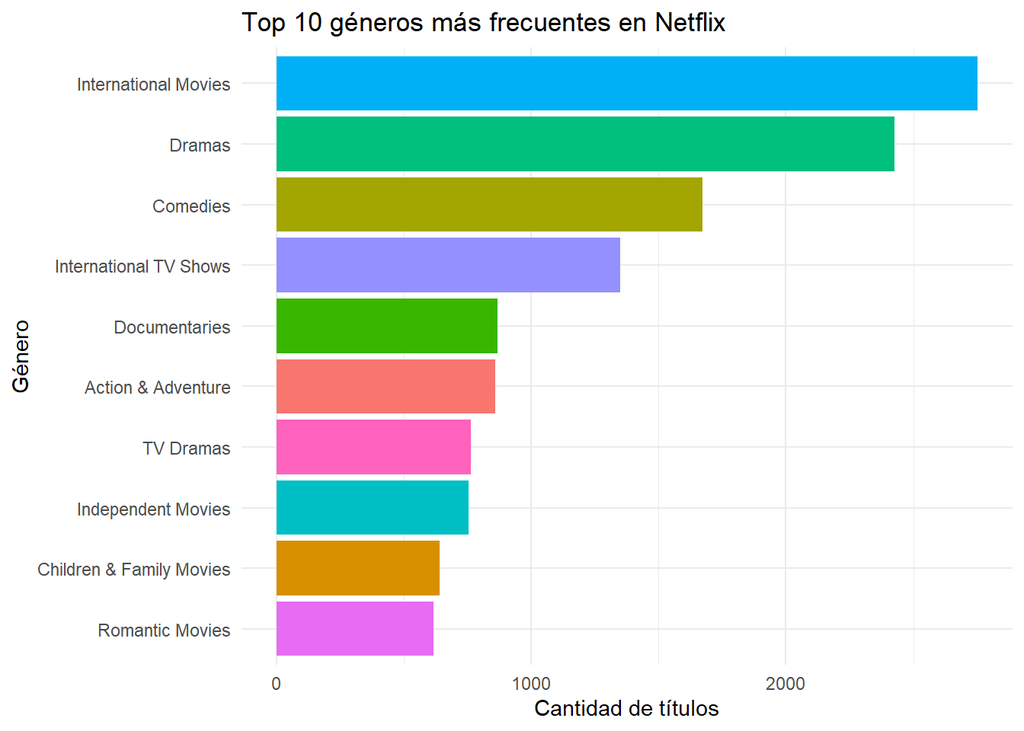

```r
# 3.1 Gráfico
tibble_3_1 %>%
  ggplot(aes(x = reorder(listed_in, n), y = n, fill = listed_in)) +
  geom_col(show.legend = FALSE) +
  coord_flip() +
  labs(title = "Top 10 géneros más frecuentes en Netflix",
       x = "Género", y = "Cantidad de títulos") +
  theme_minimal()
```

```r
# 3.2 Duración promedio de películas
netflix %>%
  filter(type == "Movie", !is.na(duration)) %>%
  mutate(minutos = as.numeric(gsub(" min", "", duration))) %>%
  summarise(promedio_minutos = mean(minutos, na.rm = TRUE))
```

```
##   promedio_minutos
## 1         99.57719
```

```r
# 3.3 Promedio de temporadas de series
netflix %>%
  filter(type == "TV Show", !is.na(duration)) %>%
  mutate(temporadas = as.numeric(gsub(" Season[s]?", "", duration))) %>%
  summarise(promedio_temporadas = mean(temporadas, na.rm = TRUE))
```

```
##   promedio_temporadas
## 1            1.764948
```

## 4. Directores y Actores Frecuentes

Este análisis revela qué directores y actores aparecen con mayor frecuencia en el catálogo de Netflix, permitiendo observar posibles tendencias o colaboraciones frecuentes.

```r
# 4.1 Directores más frecuentes (tabla)
tibble_4_1 <- netflix %>%
  filter(!is.na(director), director != "") %>%
  count(director, sort = TRUE) %>%
  slice_max(n, n = 10)
tibble_4_1
```

```
##                  director  n
## 1           Rajiv Chilaka 19
## 2  Raúl Campos, Jan Suter 18
## 3            Marcus Raboy 16
## 4             Suhas Kadav 16
## 5               Jay Karas 14
## 6     Cathy Garcia-Molina 13
## 7             Jay Chapman 12
## 8         Martin Scorsese 12
## 9         Youssef Chahine 12
## 10       Steven Spielberg 11
```

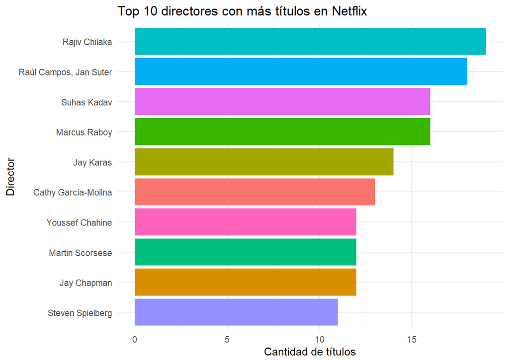

```r
# 4.1 Gráfico
tibble_4_1 %>%
  ggplot(aes(x = reorder(director, n), y = n, fill = director)) +
  geom_col(show.legend = FALSE) +
  coord_flip() +
  labs(title = "Top 10 directores con más títulos en Netflix",
       x = "Director", y = "Cantidad de títulos") +
  theme_minimal()
```

```r
# 4.2 Actores más frecuentes (tabla)
tibble_4_2 <- netflix %>%
  filter(!is.na(cast)) %>%
  separate_rows(cast, sep = ", ") %>%
  filter(cast != "") %>%
  count(cast, sort = TRUE) %>%
  slice_max(n, n = 10)
tibble_4_2
```

```
## # A tibble: 11 × 2
##    cast                 n
##    <chr>            <int>
##  1 Anupam Kher         43
##  2 Shah Rukh Khan      35
##  3 Julie Tejwani       33
##  4 Naseeruddin Shah    32
##  5 Takahiro Sakurai    32
##  6 Rupa Bhimani        31
##  7 Akshay Kumar        30
##  8 Om Puri             30
##  9 Yuki Kaji           29
## 10 Amitabh Bachchan    28
## 11 Paresh Rawal        28
```

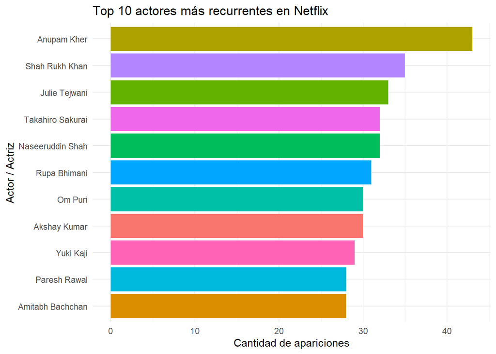

```r
# 4.2 Gráfico
tibble_4_2 %>%
  ggplot(aes(x = reorder(cast, n), y = n, fill = cast)) +
  geom_col(show.legend = FALSE) +
  coord_flip() +
  labs(title = "Top 10 actores más recurrentes en Netflix",
       x = "Actor / Actriz", y = "Cantidad de apariciones") +
  theme_minimal()
```